# Determining available habitat

12 March, 2025

## Background

This document gives an overview of the different methods I’ve considered for determining available habitat for the habitat preference work.

There is no general framework dictating how available habitat should be defined: it depends on a combination of the questions you’re asking, the study system context, and the data you have access to (Boyce *et al.* 2006). The major decisions that have to be made are (1) what habitat are you sampling from, e.g. minimum convex polygons vs kernel density estimates, and (2) what ratio of used vs available points are suitable for the analysis?

My objectives are to understand how individuals make use of the space available to them when deciding where to forage. The habitat I select from should therefore reflect what individuals are likely to be able to access. For albatrosses, individuals should be pretty free in what habitat they select, albeit within the constraints of central place foraging and the influence of wind on the energetics of their flight behaviour.

### Defining the available habitat

The concept of available habitat fundamentally depends on the scale of the study and its objectives. It encompasses areas that individuals should theoretically be able to access, considering its movement capabilities and behaviour. It can vary in scale from: the geographical range of a species, to the home range of an individual, or to specific sites within a home range. It might also include selection of particular resources within a site, but this would be more typically modelled as a resource selection function.

Northrup *et al.* (2013) suggest that habitat selected from a buffer around the used points can reduce model bias, though very large buffers come with a trade-off of computational intensity. Panton *et al.* (2016) also make the point that using spatial scales that are too large can create homogeneity and fail to capture local extremes by averaging out diverging responses. Both agree that small scales are to be avoided, as they might capture stochastic variation that isn’t relevant to the study. Panton *et al.* suggest overall that defining habitat use, with a buffer, at an individual level can be a good mechanism to avoid homogeneity (as extreme responses from individuals will still be captured).

Many papers use minimum convex polygons (e.g. Lopkucki *et al.* 2023; Meng *et al.* 2020). However there is increasing evidence that these can heavily bias findings, and a buffer-based approach or something more fluid such as a kernel density estimate may be more appropriate.

### Choosing used vs available ratios

Choosing a ratio of used to available points is not an exact science, and there is no universal standard. The optimal ratio, like the defintion of habitat, depends on the study objectives, species behaviour, and data quality.

Paton *et al.* (2016) make the point that using a small ratio can give a poor model approximation, and so meaningful inferences cannot be drawn. But it is often overlooked that large ratios can also provide poor approximations (Northrup *et al.* 2013). How availability is drawn fundamentally depends on the study system, scale of inference, and the intentions of the study. The only piece of advice that applies to all studies is to perform a **sensitivity analysis.**

### Location resolution

Thinning of location data can improve model performance by reducing issues such as spatial autocorrelation and sampling bias (i.e. due to uneven sampling effort across the study area).

Northrup *et al.* (2013) highlight that high resolution location sampling can lead to autocorrelation, which may inflate the risk of Type I error or otherwise lead to poor model fit. To avoid this, data should be either be thinned, or autocorrelation structures should be fitted in the model. In my data, I **sample for foraging locations only**. This should reduce the impact of this issue.

Another approach is put forward by Boyce *et al.* (2006), who make the point that location points should reflect the temporal scale of the variables of interest. For example, bathymetry obviously doesn’t change, and so individual responses to that could be considered on e.g. a single trip. Conversely, SST could change even within a day, and so a finer scale temporal response might be required. One statistical way to think about this is to run autocorrelation functions on the habitat variables and downsample the location data to the temporal range at which they correlate.

## Initial exploration

Because it takes a very long time to process the environmental datasets, it’s important to try to nail my ratios of used vs available points from the get-go. To do this, I’m going to focus on subsets of my data and a simplified habitat model, and look at how changing the ratios changes my effect sizes.

I’ve already decided to focus only on foraging locations (as extracted from the HMMs), so will load the labelled foraging data. Because it’s the easiest measure to work with, I’ll begin by focusing on bathymetry data.

### Dealing with potential spatial autocorrelation

Spatial autocorrelation can cause problems by inflating Type 1 error. However, as I have already reduced my dataset to foraging (‘searching’) movements only, spatial autocorrelation is very unlikely to be a major issue. This is because there are unlikely to be sufficient sequential points for strong autocorrelation that could cause problems for my results.

### Defining the available habitat and choosing a ratio

I settled on calculating minimum convex polygons (MCP) across the whole range of individuals’ GPS tracks, and then adding a 15km buffer to this. For each hour for which a bird had data, I have sampled points within the MCP range, excluding any points over land. For bathymetry, this doesn’t matter so much, but for my temporally dynamic variables this will allow me to sample across time as well as space.

I’ve sampled 10 random points per GPS point, and will iteratively subsample down to see how this changes my effects.

The structure of these points comes about because I’m sampling so thoroughly within the MCPs of individuals. There is probably a question here about whether this is actually not conservative enough - e.g. the individual foraging in the NW is very constrained to the point of their MCP, but the sampled points cover almost the entire polygon. But it’s difficult as constraining the sampling process needs to be balanced against the fact that they probably can access anywhere they want to.

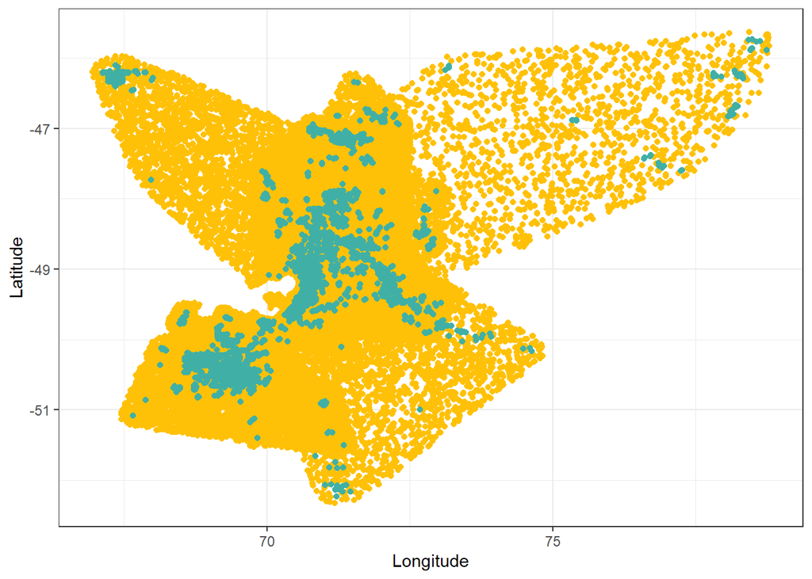

Figure 1. Yellow points = available habitat; turquoise points = used habitat. GPS points taken from a subsample of 20 birds in 2012. For each GPS point, 10 available points were subsampled.

### Testing with bathymetry

My aim here is to determine the minimum number of available points required for my analyses. To start, I’ll look at bathymetry as this is the only environmental metric where there is no temporal dynamic (i.e. it is the most simple measure). I vary the number of available points used to see how the effect of bathymetry changes with the used:available ratio.

Because I have selected a subset of individuals from one year, I am not including trip ID for now to keep the model simple. I am also not including random slopes at this stage, as there isn’t enough data here to estimate them.

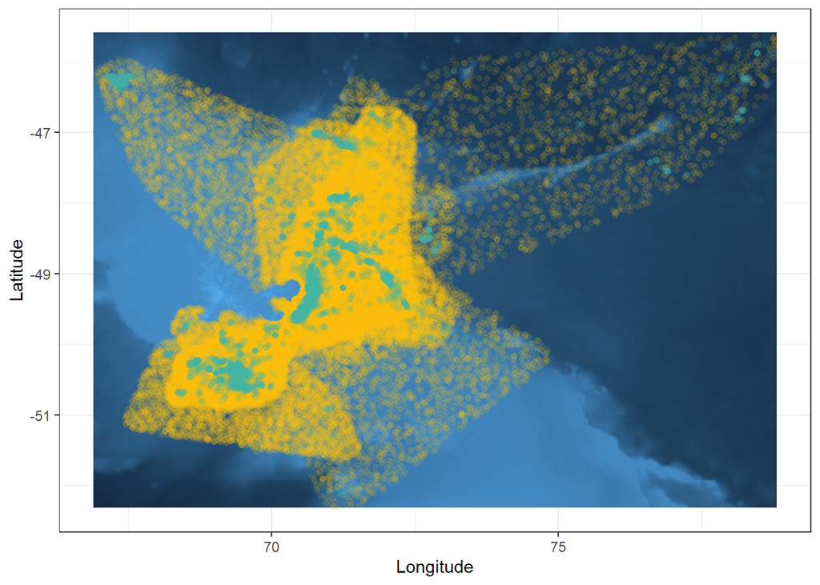

Figure 2. Available and used points displayed on bathymetry map of the study extent.

#### Bathymetry & colony distance collinearity issues

One thing to note is that there is a very high correlation between bathymetry and distance from the colony. Of course, we know this already: this is why the distance from the colony measure is included in the first place. But it also leads to multicollinearity in the model.

How do I deal with it? One option is to use residual bathymetry - i.e. bathymetry after accounting for distance from the colony, leaving only variation in bathymetry that is independent of distance. We’re asking “Do birds prefer deeper or shallower areas than expected at a given distance?”. This is what I’ve gone for, but I’m happy to revise this. I don’t think it qualifies as ‘stats on stats’ as I’m not using the same data twice - rather, I’m remodeling the confounding variables.

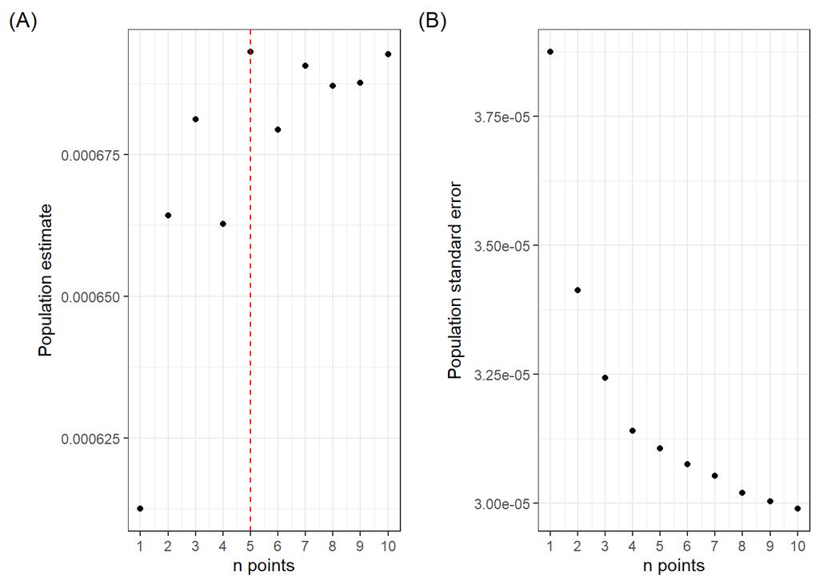

## Other species

Here I’m running the same approach on subsamples of the other datasets to see how my ratios hold up. For each species/colony, I’ve picked the year with the most number of sampled individuals.

### Sample sizes

Table 1. Sample sizes for each species, colony, and year, showing the number of individuals for which we have more than 1 foraging trip.

| Species | Colony | 1989 | 1991 | 1992 | 1993 | 1994 | 1996 | 1998 | 1999 | 2000 | 2001 | 2002 | 2003 | 2004 | 2005 | 2006 | 2008 | 2010 | 2011 | 2012 | 2013 | 2014 | 2015 | 2016 | 2017 | 2018 | 2019 | 2020 | 2021 | … |
| --- | --- | --- | --- | --- | --- | --- | --- | --- | --- | --- | --- | --- | --- | --- | --- | --- | --- | --- | --- | --- | --- | --- | --- | --- | --- | --- | --- | --- | --- | --- |
| WAAL | Crozet | 2 | 0 | 2 | 0 | 0 | 0 | 4 | 9 | 1 | 5 | 0 | 5 | 0 | 0 | 0 | 10 | 1 | 9 | 1 | 36 | 6 | 7 | 22 | 10 | 13 | 19 | 1 | 0 | … |
|  | Bird Island | 0 | 4 | 4 | 0 | 0 | 1 | 12 | 0 | 1 | 0 | 0 | 3 | 5 | 0 | 0 | 0 | 2 | 0 | 3 | 0 | 0 | 0 | 0 | 0 | 0 | 0 | 0 | 0 | … |
| BBAL | Bird Island | 0 | 0 | 0 | 2 | 1 | 0 | 0 | 0 | 0 | 0 | 12 | 0 | 0 | 0 | 1 | 2 | 2 | 0 | 0 | 0 | 0 | 24 | 0 | 0 | 0 | 8 | 9 | 3 | … |
|  | Kerguelen | 0 | 0 | 0 | 0 | 0 | 0 | 0 | 0 | 0 | 0 | 0 | 0 | 1 | 1 | 1 | 0 | 0 | 0 | 69 | 10 | 4 | 10 | 0 | 0 | 0 | 0 | 0 | 0 | … |

### BBAL at Bird Island

For this section, 20 individuals were sampled from 2015.

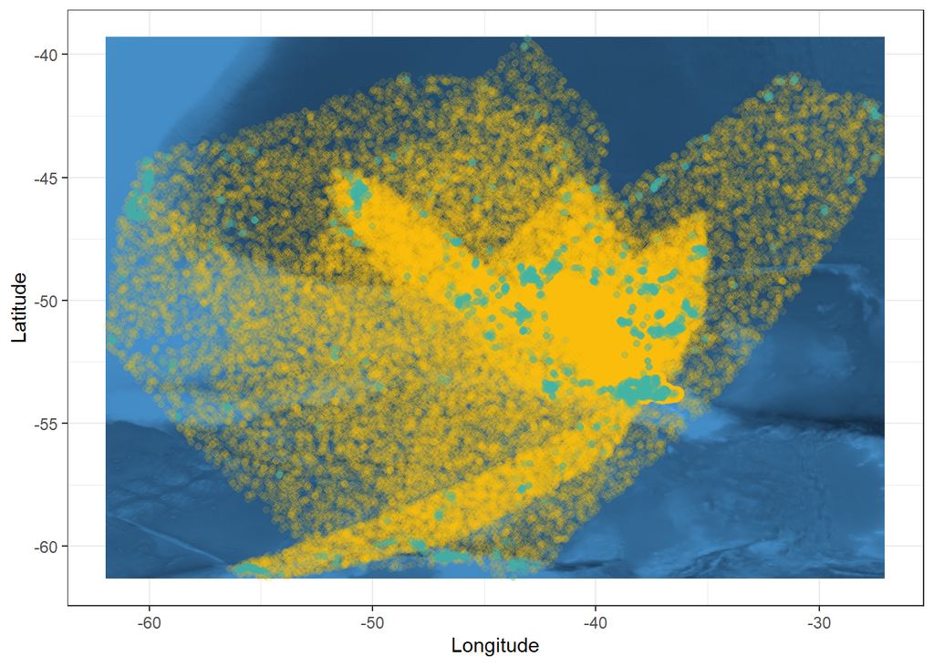

Figure 4. Available and used points displayed on bathymetry map of the study extent for black-browed albatrosses breeding at Bird Island.

#### Modelling bathymetry

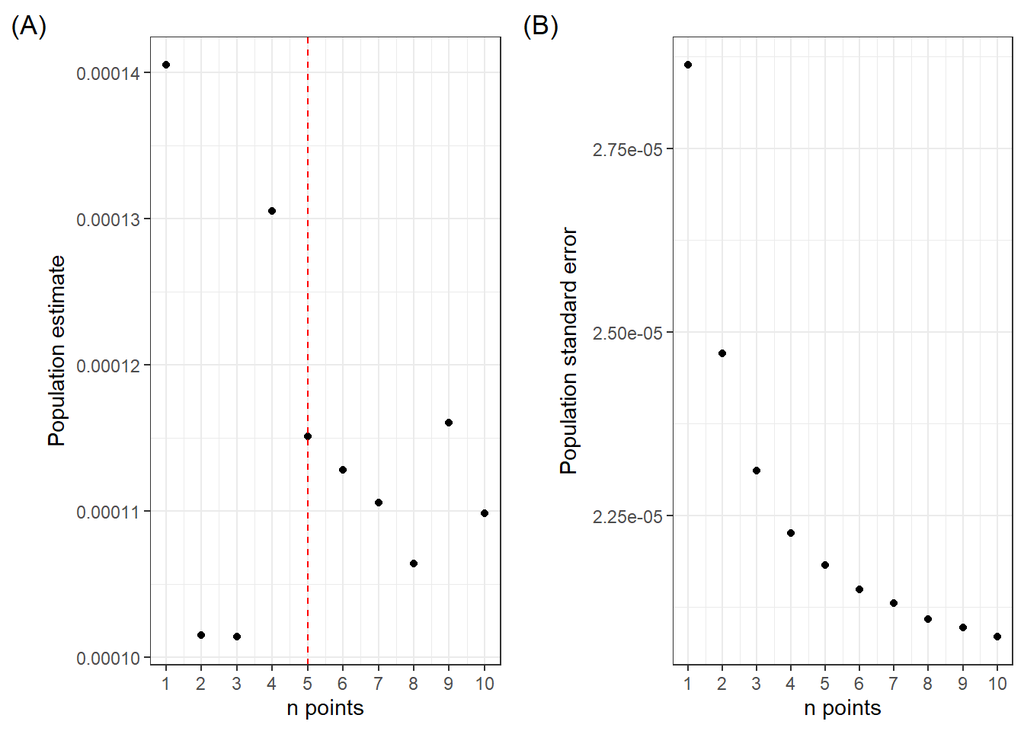

### WAAL at Crozet

For this section, 20 individuals were sampled from 2013.

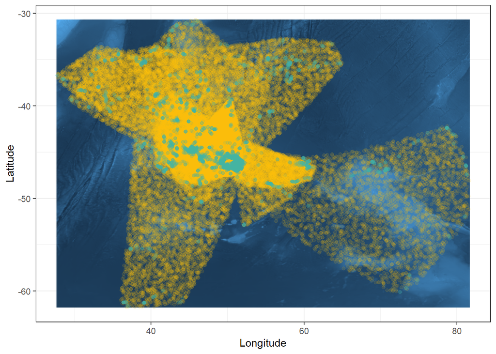

Figure 6. Available and used points displayed on bathymetry map of the study extent for wandering albatrosses breeding at Crozet.

#### Modelling bathymetry

Here, the estimate seem to stabilise at around a 6:1 ratio.

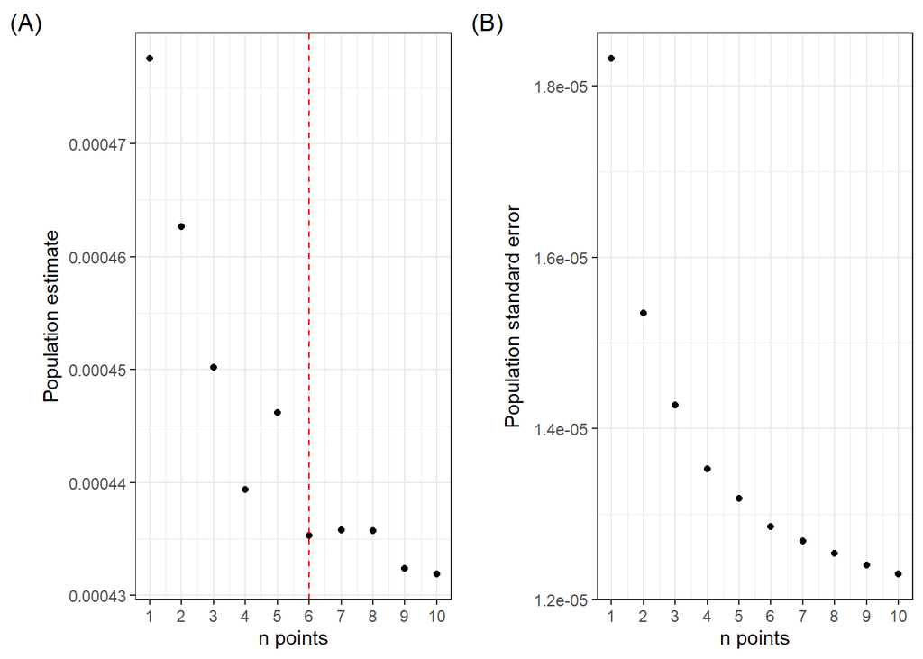

### WAAL at Bird Island

For this section, 20 individuals were sampled from 2022.

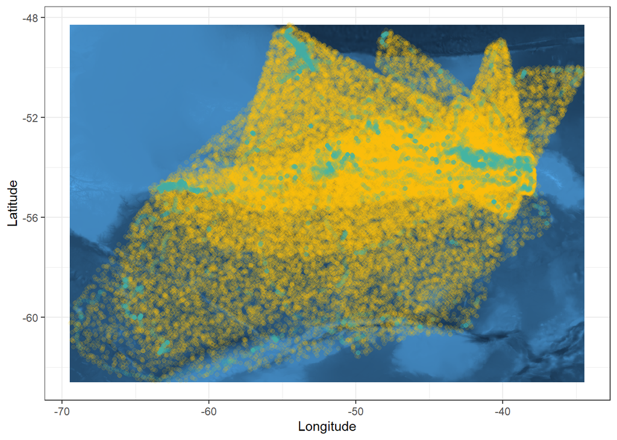

Figure 8 Available and used points displayed on bathymetry map of the study extent for wandering albatrosses breeding at Bird Island

#### Modelling bathymetry

Here, it looks like estimates settle at a 6:1 available:used ratio, as for the Crozet WAAL.

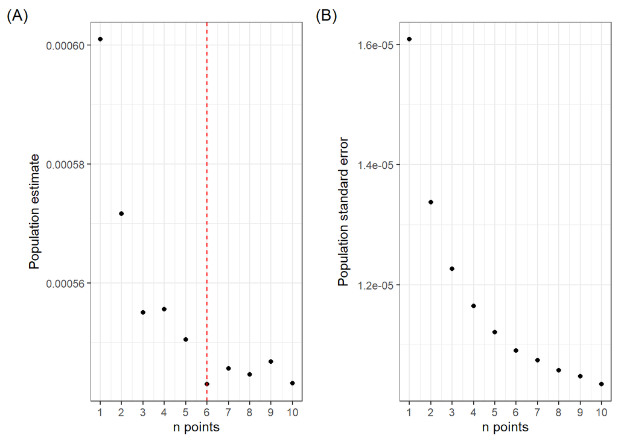

## References

Boyce, M.S. (2006), Scale for resource selection functions. *Diversity and Distributions, 12*(3): 269-276. https://doi.org/10.1111/j.1366-9516.2006.00243.x

Łopucki, R., Klich, D., Perzanowski, K., Nieszała, A., Kiersztyn, A., Bołbot, A., Sobczuk, M., & Olech, W. (2023). Individual differentiation of habitat preferences indicate high flexibility in habitat use by European bison (Bison bonasus). *Global Ecology and Conservation*, *44*, Article e02494. https://doi.org/10.1016/j.gecco.2023.e02494

Meng, F., Wang, X., Batbayar, N., Natsagdorj, T., Davaasuren, B., Damba, I., Cao, L., & Fox, A. D. (2020). Consistent habitat preference underpins the geographically divergent autumn migration of individual Mongolian common shelducks. *Current Zoology*, *66*(4), 355–362. https://doi.org/10.1093/cz/zoz056

Northrup, J.M., Hooten, M.B., Anderson, C.R., Jr. and Wittemyer, G. (2013), Practical guidance on characterizing availability in resource selection functions under a use–availability design. *Ecology, 94*(7): 1456-1463. https://doi.org/10.1890/12-1688.1

Paton, R.S. and Matthiopoulos, J. (2016), Defining the scale of habitat availability for models of habitat selection. *Ecology, 97*(5): 1113-1122. https://doi.org/10.1890/14-2241.1